# Chapter 5 Notes

Jack Nystrom

AP Chemistry

Chapter 5 Notes - Gases

**Barometer**: A device to measure atmospheric pressure, invented in 1643. Uses a glass tube filled with liquid mercury, placed face down into a cup also filled with mercury. The amount of mercury that stays in the tube corresponds with the atmospheric pressure exerted on the mercury in the cup.

**Manometer**: A device to measure pressure by comparison, also utilizing mercury.

Pressure = Force / Area

Since many devices used to measure pressure use mercury, one major unit for pressure that was established was mm Hg (millimeters of mercury), also known as the torr. Another is the standard atmosphere (atm).

1 atm = 760 mmHg = 760 torr

In SI Units, force is Newtons and area is m<sup>2</sup>. Thus the SI unit for pressure, the **pascal** (Pa), is N/m<sup>2</sup>.

1 atm = 101,325 Pa = 101.325 kPa

Boyle’s Law: P<sub>1</sub>V<sub>1</sub> = P<sub>2</sub>V<sub>2</sub>

Charles's Law: V<sub>1</sub>/T<sub>1</sub> = V<sub>2</sub>/T<sub>2</sub>

Avogadro’s Law: “Equal volumes of gases at the same temperature and pressure contain the same number of ‘particles.’”

Ideal Gas Law: PV = nRT, where n is the number of moles of gas particles, and R is the universal gas constant, equal to 0.08206 L*atm / K*mol.

**Standard Temperature and Pressure** (STP): The conditions 0°C and 1 atm.

**Molar Volume**: The ratio of the volume occupied by a substance to the amount of substance. Similar to molar mass.

The molar volume of any gas at STP is 22.42L.

Molar mass = $\frac{dRT}{P}$. Derivation:

n (from the ideal gas law) is # of moles of a gas, and thus can also be expressed as

$\frac{grams\ of\ gas}{molar\ mass}\ = \ \frac{g}{g/mol}\$

From *P**V* = *n**R**T*, $P = \frac{nRT}{V} = \frac{(m/molar\ mass)RT}{V} = \frac{mRT}{V(molar\ mass)}$.

$\frac{m}{V}$ is density (d), thus $P = \frac{dRT}{(molar\ mass)}$, or $Molar\ Mass = \frac{dRT}{P}$ (density * R * temp / pressure).

**Dalton’s law of partial pressures**: For a mixture of gases in a container, the total pressure exerted is the sum of the pressures that each gas would exert if it were alone.

P<sub>total</sub> = P<sub>1</sub> + P<sub>2</sub> + P<sub>3</sub> + … = n<sub>1</sub>RT/V + n<sub>2</sub>RT/V + n<sub>2</sub>RT/V + … = (n<sub>1</sub> + n<sub>2</sub> + n<sub>3</sub> + …)RT/V = n<sub>total</sub>RT/V

**Kinetic Molecular Theory** (KMT): a simple model that attempts to explain the properties of an ideal gas. It states:

1. The volume occupied by the individual particles of a gas is negligible compared to the volume of the gas itself (zero).
2. The particles of an ideal gas exert no attractive forces on each other or on their surroundings.
3. Gas particles are in a constant state of random motion and move in straight lines until they collide with another body.
4. The average kinetic energy of gas molecules is directly proportional to absolute temperature (K) only; this implies that all molecular motion ceases if the temperature is reduced to absolute zero.

**Root Mean Squared Velocity**: the average of the *squares* of the velocities of gas particles, represented by u<sub>rms</sub>. Eg: u<sub>rms</sub> for O<sub>2</sub> is about 500m/s.

R is the universal gas constant *but using different numerator units;* J / k*mol instead of L*atm / k*mol (volume*pressure is a form of energy!). The value of this R = 8.3145 J / k*mol.

**Defusion**: the mixing of gases. **Effusion**: the passage of a gas through a tiny orifice into an evacuated chamber.

**Graham’s law of effusion**:

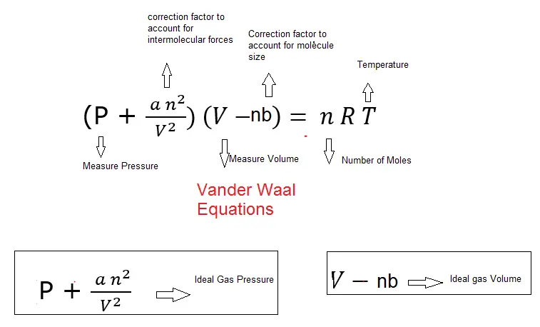

**van der Waals equation**:

Essentially PV=nRT but with corrected values for P and V. The values for a and b are determined purely experimentally; that is, finding the right values for a and b until the best fit of the observed pressure is obtained under all conditions.